# games

| Проект: Анализ мирового рынка видеоигр с 1980 по 2016 годы (с прогнозами на 2017) |
| --- |

### План исследования:

1) **Импортировать подобранные данные, и провести их первичный осмотр**

2) **Произвести предобработку, обработав и исправив:**

```
    - Названия столбцов
    - Пропуски в данныхв
    - Дубликаты
    - Типы данных
```

А также путем вычеслений преобразовав новые данные

3) **Осуществить исследовательский анализ, а именно:**

```
   - Выявить акьтвность выпуска видеоигр по годам
   - Определить наиболее успешные компании выпуска видеоигр во временном промежутке (по критерием выпускаемости и продоваемости видеоигр)
   - Отследить, как менялись продажи по платформам. Определить средний период популярности отдельной платформы
   - Определить потенциальных лидеров на 2017 год
   - Выявить, как влияют на продажи внутри отдельной платформы отзывы пользователей и критиков. Сравнить состояние по выборке из платформ
   - Отобразить распределение игр по жанрам (по тем же критериям: выпускаемость и продоваемость)
```

4) **Составить портрет пользователя каждого региона и сравнить их**

```
   - Самые популярные платформы (топ-5)
   - Самые популярные жанры (топ-5)
   - Влияние рейтинга ESRB на продажи в отдельном регионе
```

5) **Осуществить проверку статистических гипотез**

```
    - Средние пользовательские рейтинги платформ Xbox One и PC одинаковые;
    - Средние пользовательские рейтинги жанров Action (англ. «действие», экшен-игры) и Sports (англ. «спортивные соревнования») разные.
```

6) **Подвести итоги работы**

### Цель исследования:

Выявить тенденции пользовательского интереса к конкретным игровым платформам во временном разрезе, для передачи информации разработчикам видеоигр о перспективных игровых платформах

### Набор данных

[output not shown]

### Импорт библиотек

```python
#Импортируем необходимые библиотеки
import pandas as pd
import matplotlib.pyplot as plt
import numpy as np
import seaborn as sns
from matplotlib import cm
from scipy import stats as st
```

### Знакомство с данными

```python
#Отрываем датафрейм и выводим первые строки

filename = 'games.csv'

try:
    # Попытка прочитать данные из файла CSV
    games = pd.read_csv(filename)
    print("Файл успешно прочитан:")
    display(data.head())
except FileNotFoundError:
    # Обработка случая, когда файл не найден
    print(f"Файл '{filename}' не найден. Пожалуйста, проверьте путь к файлу.")
except Exception as e:
    # Обработка всех остальных типов исключений
    print(f"Произошла ошибка при чтении файла '{filename}': {e}")
```

```
Файл успешно прочитан:
Произошла ошибка при чтении файла 'games.csv': name 'data' is not defined
```

```python
#Смотрим общую информацию о данныых
games.info()
```

```
<class 'pandas.core.frame.DataFrame'>
RangeIndex: 16715 entries, 0 to 16714
Data columns (total 11 columns):
 #   Column           Non-Null Count  Dtype
---  ------           --------------  -----
 0   Name             16713 non-null  object
 1   Platform         16715 non-null  object
 2   Year_of_Release  16446 non-null  float64
 3   Genre            16713 non-null  object
 4   NA_sales         16715 non-null  float64
 5   EU_sales         16715 non-null  float64
 6   JP_sales         16715 non-null  float64
 7   Other_sales      16715 non-null  float64
 8   Critic_Score     8137 non-null   float64
 9   User_Score       10014 non-null  object
 10  Rating           9949 non-null   object
dtypes: float64(6), object(5)
memory usage: 1.4+ MB
```

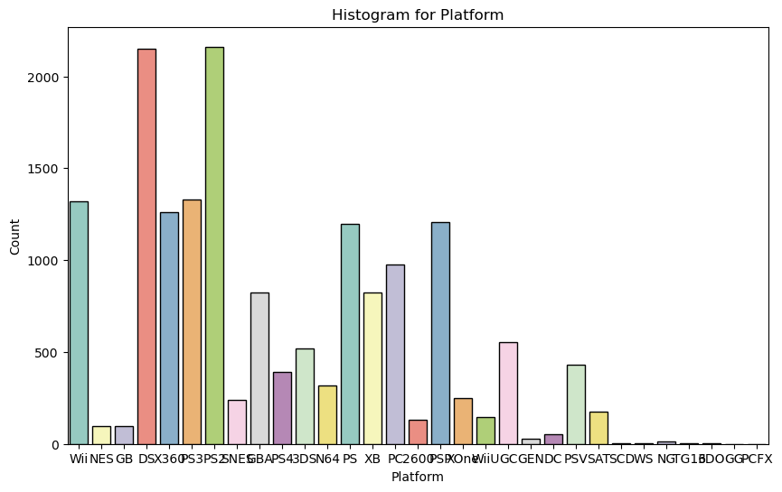

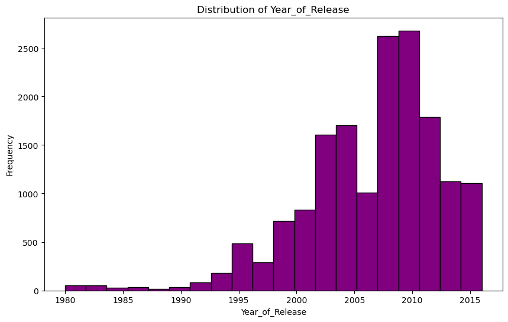

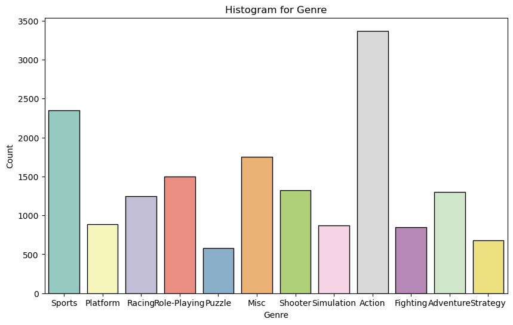

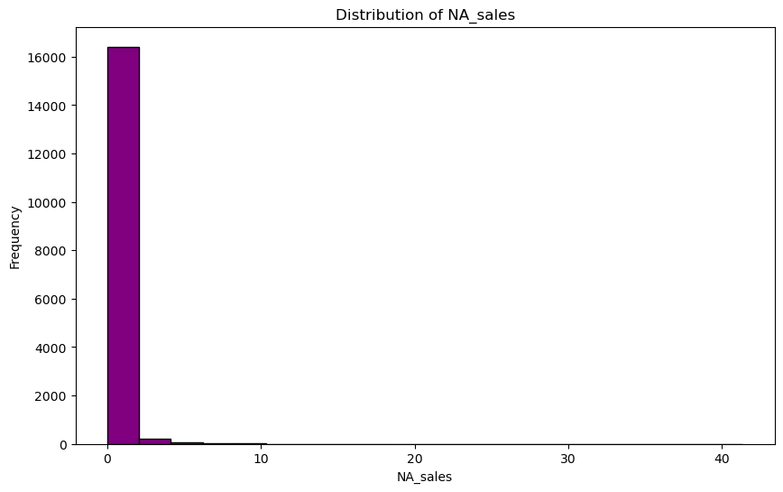

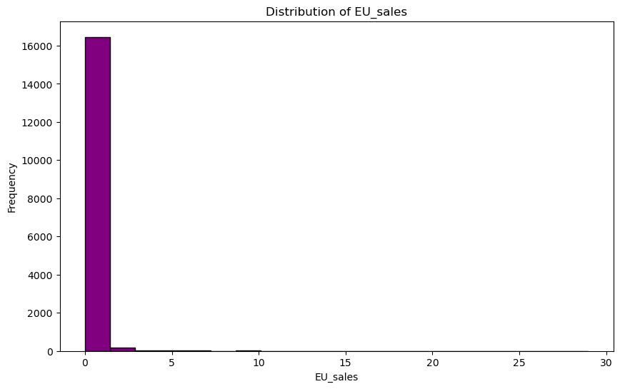

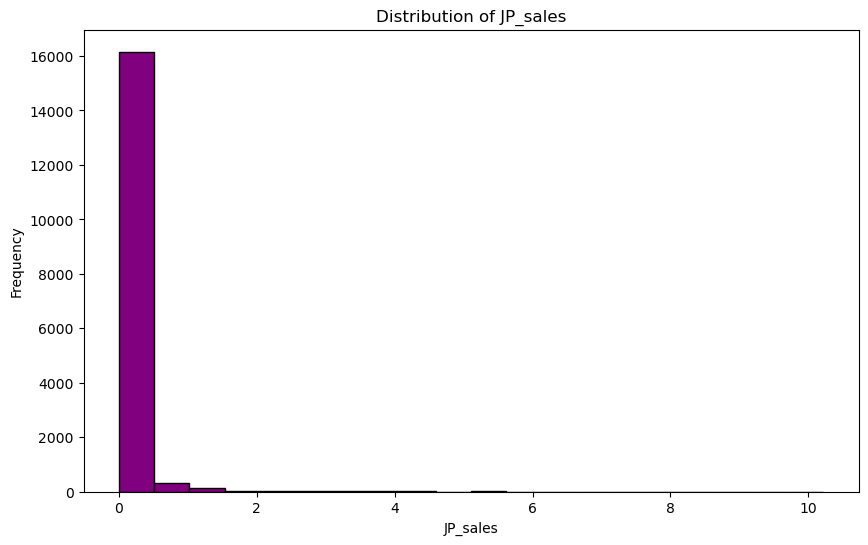

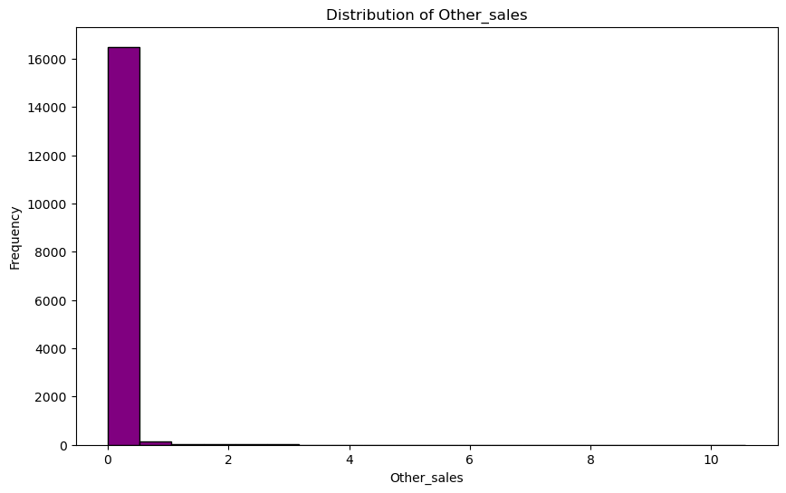

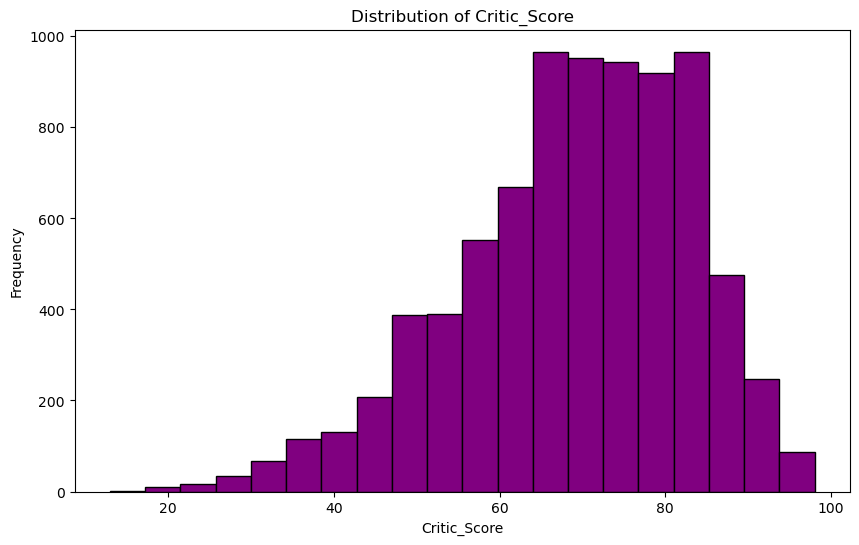

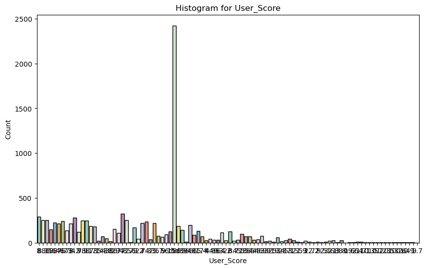

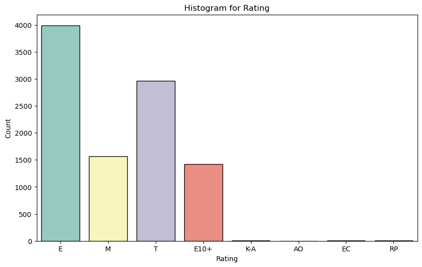

```python
# Предполагается, что data - это ваш DataFrame
for column in games.columns:
    if column != 'Name':  # Пропускаем качественные данные

        plt.figure(figsize=(10, 6))
        if games[column].dtype == 'object':  # Для категориальных данных
            sns.countplot(x=column, data=games, palette='Set3', edgecolor='black')
            plt.title(f'Histogram for {column}')
            plt.xlabel(column)
            plt.ylabel('Count')
        elif games[column].dtype == 'int64' or games[column].dtype == 'float64':  # Для числовых данных
            if games[column].nunique() < 30:  # Проверяем, является ли переменная дискретной
                sns.countplot(x=column, data=games, palette='Set3', edgecolor='black')
                plt.title(f'Distribution of {column} (Discrete)')
                plt.xlabel(column)
                plt.ylabel('Count')
            else:
                plt.hist(games[column], bins=20, color='purple', edgecolor='black')
                plt.title(f'Distribution of {column}')
                plt.xlabel(column)
                plt.ylabel('Frequency')
        plt.show()
```

Имеются пропуски и некорректные форматы данных. Перейдем к предобработке

### Предобработка данных

#### Работа с названиями переменных

```python
#Изменяем стиль названий переменных
games = games.rename(columns={'Name':'name', 'Platform': 'platform', 'Year_of_Release':'year_of_release', 'Genre':'genre', 'NA_sales':'na_sales', 'EU_sales':'eu_sales', 'JP_sales':'jp_sales', "Other_sales":"other_sales", 'Critic_Score':'critic_score', 'User_Score':'user_score', 'Rating':'rating'})

games.columns
```

```
Index(['name', 'platform', 'year_of_release', 'genre', 'na_sales', 'eu_sales',
       'jp_sales', 'other_sales', 'critic_score', 'user_score', 'rating'],
      dtype='object')
```

#### Преобразование новых данных

```python
#Создаем переменную с суммарными продажами по всем регионам
games["sum_sales"] = games["na_sales"] + games["eu_sales"] + games["jp_sales"] + games["other_sales"]
```

#### Обработка пропусков

```python
# пропущенные значения бары

def pass_value_barh(df):
    try:
        (
            (df.isna().mean()*100)
            .to_frame()
            .rename(columns = {0:'space'})
            .query('space > 0')
            .sort_values(by = 'space', ascending = True)
            .plot(kind = 'barh', figsize = (19,6), rot = -5, legend = False, fontsize = 16)
            .set_title('Доля пропусков' + "\n", fontsize = 22)
        );
        plt.xlim(0, 70)
        plt.xlabel("Доля пропусков")
        plt.ylabel("Переменные")
    except:
        print('пропусков не осталось :) или произошла ошибка в первой части функции ')
```

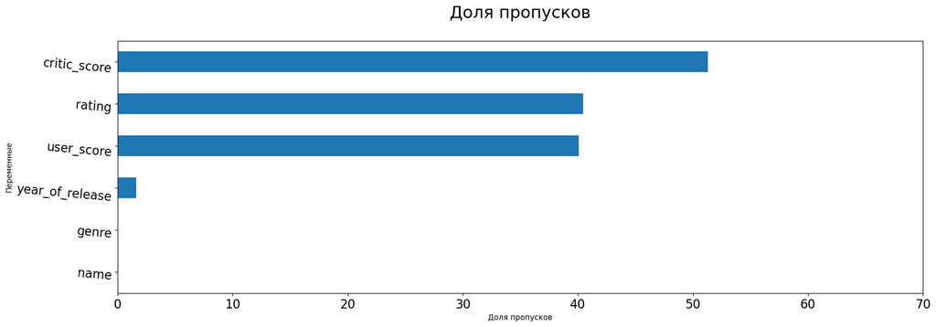

```python
pass_value_barh(games)
```

Так, мы наблюдаем что отсутствуют значения "year_of_release", "critic_score", "user_score", "rating". В годах выпуска отсутствует небольшое количество значений. Больше всего пропусков в оценках и рейтингах. Пропусвки в них занимают существенную долю.

**Перейдем к работе с пропускам по выделенным переменным**

##### year_of_release

Начнем с года выпуска, так как это переменная находится в отдельной категории и имеет меньше всего пропусков

```python
#Смотрим нулевые значения по годам
games.loc[games[games['year_of_release'].isnull() == True].index]["name"].value_counts().head(10)
```

```
name
LEGO Harry Potter: Years 5-7         7
Happy Feet Two                       4
Rock Band                            4
Test Drive Unlimited 2               3
Bejeweled 3                          3
WRC: FIA World Rally Championship    3
Singularity                          2
NBA Live 2003                        2
Silent Hill: Homecoming              2
Rock Revolution                      2
Name: count, dtype: int64
```

```python
# check
# Подсчитываем жизненный срок платформы

years_of_life = games.pivot_table(index='platform',values='year_of_release',aggfunc=['min','max'])
years_of_life.columns=['min','max']
years_of_life['years_of_life']=years_of_life['max']-years_of_life['min']
years_of_life.head(15)

# years_of_life.sort_values(by = 'years_of_life', ascending = False)
```

| platform | min | max | years_of_life |
| --- | --- | --- | --- |
| 2600 | 1980.0 | 1989.0 | 9.0 |
| 3DO | 1994.0 | 1995.0 | 1.0 |
| 3DS | 2011.0 | 2016.0 | 5.0 |
| DC | 1998.0 | 2008.0 | 10.0 |
| DS | 1985.0 | 2013.0 | 28.0 |
| GB | 1988.0 | 2001.0 | 13.0 |
| GBA | 2000.0 | 2007.0 | 7.0 |
| GC | 2001.0 | 2007.0 | 6.0 |
| GEN | 1990.0 | 1994.0 | 4.0 |
| GG | 1992.0 | 1992.0 | 0.0 |
| N64 | 1996.0 | 2002.0 | 6.0 |
| NES | 1983.0 | 1994.0 | 11.0 |
| NG | 1993.0 | 1996.0 | 3.0 |
| PC | 1985.0 | 2016.0 | 31.0 |
| PCFX | 1996.0 | 1996.0 | 0.0 |

```python
#Смотрим сколько пропусков
print('Доля пропусков в годе выпуска:')
games["year_of_release"].isna().sum()
```

```
Доля пропусков в годе выпуска:
```

[output not shown]

```python
#Открываем срез с пропусками
games[games['year_of_release'].isnull() == True].head()
```

|  | name | platform | year_of_release | genre | na_sales | eu_sales | jp_sales | other_sales | critic_score | user_score | rating | sum_sales |
| --- | --- | --- | --- | --- | --- | --- | --- | --- | --- | --- | --- | --- |
| 183 | Madden NFL 2004 | PS2 | NaN | Sports | 4.26 | 0.26 | 0.01 | 0.71 | 94.0 | 8.5 | E | 5.24 |
| 377 | FIFA Soccer 2004 | PS2 | NaN | Sports | 0.59 | 2.36 | 0.04 | 0.51 | 84.0 | 6.4 | E | 3.50 |
| 456 | LEGO Batman: The Videogame | Wii | NaN | Action | 1.80 | 0.97 | 0.00 | 0.29 | 74.0 | 7.9 | E10+ | 3.06 |
| 475 | wwe Smackdown vs. Raw 2006 | PS2 | NaN | Fighting | 1.57 | 1.02 | 0.00 | 0.41 | NaN | NaN | NaN | 3.00 |
| 609 | Space Invaders | 2600 | NaN | Shooter | 2.36 | 0.14 | 0.00 | 0.03 | NaN | NaN | NaN | 2.53 |

Интересный факт, что в названиях некоторых игр находится пропущенная дата релиза. Хоть это и совершенно незначительная часть, сделаем эту замену.

Заменим пропуски на нули

```python
#Замена
games.loc[games["year_of_release"].isnull() == True, "year_of_release"] = 0

pd.options.mode.chained_assignment = None
year = []
years = []

#Напишем код, для замены пропусков в дате релиза, в тех местах, где дата расположена в названии игры
for i in games[games['year_of_release'] == 0].index:
    for j in games["name"][i]:
        if j in ["0", "1", "2", "3", "4", "5", "6", "7", "8", "9"]:
            year.append(j)
    if len(year) > 3:
        games['year_of_release'][i] = int("".join(year))
    year = []

#Убедимся, что все заменилось
games["year_of_release"].unique()
```

[output not shown]

```python
#Смотрим сколько пропусков
games.loc[games["year_of_release"] == 0]["name"].count()
```

[output not shown]

```python
#Какой процент занимают данные без года от общего массива
print(games.loc[games["year_of_release"] == 0, "year_of_release"].count() / games["name"].count())
print(games.loc[games["year_of_release"] == 0, "sum_sales"].sort_values())

#Таких данных около процента, а продажи у таких игр не превышают 3 млн.
#Следовательно их удаление не отразится на исследовании популярных платформ. Удалим эти значения
games = games.loc[games['year_of_release'] != 0]
```

```
0.015018249267037636
16522    0.01
15816    0.01
15966    0.01
16017    0.01
16059    0.01
         ...
678      2.33
657      2.40
627      2.47
609      2.53
456      3.06
Name: sum_sales, Length: 251, dtype: float64
```

```python
#Смотрим сколько пропусков
games.loc[games["year_of_release"] == 0]["name"].count()
```

```
0
```

##### name & genre

```python
#Отследим в какиъ наблюдениях пропуски совпадают
games.loc[games["name"].isna() & games["genre"].isna()]

#Пропуски по жанру и по имени присутствуют в одних и тех же наблюдениях в малом количестве.
#Соответственно их можно и даже нужно удалить

#Исключим значения с пропуском в жанре и в имени
games.dropna(axis = 'index', subset = ['name'], inplace = True)
games.info()

games.loc[games["name"].isna()].index
```

```
<class 'pandas.core.frame.DataFrame'>
Index: 16462 entries, 0 to 16714
Data columns (total 12 columns):
 #   Column           Non-Null Count  Dtype
---  ------           --------------  -----
 0   name             16462 non-null  object
 1   platform         16462 non-null  object
 2   year_of_release  16462 non-null  float64
 3   genre            16462 non-null  object
 4   na_sales         16462 non-null  float64
 5   eu_sales         16462 non-null  float64
 6   jp_sales         16462 non-null  float64
 7   other_sales      16462 non-null  float64
 8   critic_score     7996 non-null   float64
 9   user_score       9852 non-null   object
 10  rating           9780 non-null   object
 11  sum_sales        16462 non-null  float64
dtypes: float64(7), object(5)
memory usage: 1.6+ MB
```

```
Index([], dtype='int64')
```

##### critic_score & user_score & rating

Только в трех переменных отсутствуют значения в большом количестве: **в переменных с пользовательским и экспертным рейтингами, а также с рейтингом от организаций (ESRB).**

```python
#Рассмотрим уникальные значения
games["user_score"].unique()
```

```
array(['8', nan, '8.3', '8.5', '6.6', '8.4', '8.6', '7.7', '6.3', '7.4',
       '8.2', '9', '7.9', '8.1', '8.7', '7.1', '3.4', '5.3', '4.8', '3.2',
       '8.9', '6.4', '7.8', '7.5', '2.6', '7.2', '9.2', '7', '7.3', '4.3',
       '7.6', '5.7', '5', '9.1', '6.5', 'tbd', '8.8', '6.9', '9.4', '6.8',
       '6.1', '6.7', '5.4', '4', '4.9', '4.5', '9.3', '6.2', '4.2', '6',
       '3.7', '4.1', '5.8', '5.6', '5.5', '4.4', '4.6', '5.9', '3.9',
       '3.1', '2.9', '5.2', '3.3', '4.7', '5.1', '3.5', '2.5', '1.9', '3',
       '2.7', '2.2', '2', '9.5', '2.1', '3.6', '2.8', '1.8', '3.8', '0',
       '1.6', '9.6', '2.4', '1.7', '1.1', '0.3', '1.5', '0.7', '1.2',
       '2.3', '0.5', '1.3', '0.2', '0.6', '1.4', '0.9', '1', '9.7'],
      dtype=object)
```

В значениях присутствует такой элемент, как tbd что означает - будет оценено. Поскольку оценка на данный момент отсутствует, заменим на пропуски, чтобы можно было перемести переменную в числовой формат

```python
#Заменяем на пропуски
games.loc[games["user_score"] == "tbd", "user_score"] = np.nan
#Проверяем
games.loc[games["user_score"] == "tbd"]
```

|  | name | platform | year_of_release | genre | na_sales | eu_sales | jp_sales | other_sales | critic_score | user_score | rating | sum_sales |
| --- | --- | --- | --- | --- | --- | --- | --- | --- | --- | --- | --- | --- |

```python
games[['critic_score', 'user_score', 'rating']].isnull().corr()
```

|  | critic_score | user_score | rating |
| --- | --- | --- | --- |
| critic_score | 1.000000 | 0.799410 | 0.783011 |
| user_score | 0.799410 | 1.000000 | 0.732882 |
| rating | 0.783011 | 0.732882 | 1.000000 |

Итак, пропущенные значения очень активно коррелируют друг с другом, причем положительно, что означает, что пропуски в одной переменной относительно соответствуют пропускам в других двух.

Соответствено, есть вероятность, что во всех трех переменных в одних и тех же наблюдениях отсутствуют значения. Проверим это

```python
games.loc[games["user_score"].isna() & games["rating"].isna() & games["critic_score"].isna()]["name"].count()
```

```
6585
```

```python
#создаем столбец для маркеров
games["no_scored"] = 0

#маркеруем пропуски единицами
games.loc[games["user_score"].isna() & games["rating"].isna() & games["critic_score"].isna(), "no_scored"] = 1
```

```python
#Заменяем пропуски на
games.loc[games["no_scored"] == 1, "user_score"] = 0
games.loc[games["no_scored"] == 1, "rating"] = 0
games.loc[games["no_scored"] == 1, "critic_score"] = 0
```

```python
games.info()
```

```
<class 'pandas.core.frame.DataFrame'>
Index: 16462 entries, 0 to 16714
Data columns (total 13 columns):
 #   Column           Non-Null Count  Dtype
---  ------           --------------  -----
 0   name             16462 non-null  object
 1   platform         16462 non-null  object
 2   year_of_release  16462 non-null  float64
 3   genre            16462 non-null  object
 4   na_sales         16462 non-null  float64
 5   eu_sales         16462 non-null  float64
 6   jp_sales         16462 non-null  float64
 7   other_sales      16462 non-null  float64
 8   critic_score     14581 non-null  float64
 9   user_score       14059 non-null  object
 10  rating           16365 non-null  object
 11  sum_sales        16462 non-null  float64
 12  no_scored        16462 non-null  int64
dtypes: float64(7), int64(1), object(5)
memory usage: 1.8+ MB
```

#### Изменение типов данных

Года измеряются в целых числах (в данных не указаны месяца, только года)

```python
#Меняем год релиза на целочисленный тип

games["year_of_release"] = games["year_of_release"].astype("int")
```

Там, где пользовательский рейтинг имеется, он измеряется в числах с плавующей точкой, (то есть бал и дробная доля), так что заменим тип на флот

```python
#Меняем рейтинг на числовой формат
games["user_score"] = games["user_score"].astype("float64")
```

```python
#Проверим, что все форматы заменились
games.info()
```

```
<class 'pandas.core.frame.DataFrame'>
Index: 16462 entries, 0 to 16714
Data columns (total 13 columns):
 #   Column           Non-Null Count  Dtype
---  ------           --------------  -----
 0   name             16462 non-null  object
 1   platform         16462 non-null  object
 2   year_of_release  16462 non-null  int32
 3   genre            16462 non-null  object
 4   na_sales         16462 non-null  float64
 5   eu_sales         16462 non-null  float64
 6   jp_sales         16462 non-null  float64
 7   other_sales      16462 non-null  float64
 8   critic_score     14581 non-null  float64
 9   user_score       14059 non-null  float64
 10  rating           16365 non-null  object
 11  sum_sales        16462 non-null  float64
 12  no_scored        16462 non-null  int64
dtypes: float64(7), int32(1), int64(1), object(4)
memory usage: 1.7+ MB
```

#### Проверка дубликатов

```python
#Проверяем на наличие явных дубликатов
games.duplicated().sum()
```

```
0
```

Также проверим дубликаты по ключевым столбцам

```python
games.shape
```

```
(16462, 13)
```

```python
#Создадим копию
games_check = games

#приведем значения к нижнему регистру
games_check["name"].str.lower()
games_check["platform"].str.lower()

#Найдем ииндексы неполных дубликатов
drop = games_check[games_check[['name', 'platform', 'year_of_release']].duplicated()].index

#удалим неполные дубликаты
games = games.drop(drop)
```

Явные дубликаты отсутствуют, неполные - удалены, двигаемся дальше

```python
games.info()
```

```
<class 'pandas.core.frame.DataFrame'>
Index: 16461 entries, 0 to 16714
Data columns (total 13 columns):
 #   Column           Non-Null Count  Dtype
---  ------           --------------  -----
 0   name             16461 non-null  object
 1   platform         16461 non-null  object
 2   year_of_release  16461 non-null  int32
 3   genre            16461 non-null  object
 4   na_sales         16461 non-null  float64
 5   eu_sales         16461 non-null  float64
 6   jp_sales         16461 non-null  float64
 7   other_sales      16461 non-null  float64
 8   critic_score     14580 non-null  float64
 9   user_score       14058 non-null  float64
 10  rating           16364 non-null  object
 11  sum_sales        16461 non-null  float64
 12  no_scored        16461 non-null  int64
dtypes: float64(7), int32(1), int64(1), object(4)
memory usage: 1.7+ MB
```

### Исследовательский анализ

В рамках ИА блока выполним установленные в плане исследователские задачи. Каждая задача находится в отдельном блоке

#### Анализ активности выпуска игр по годам

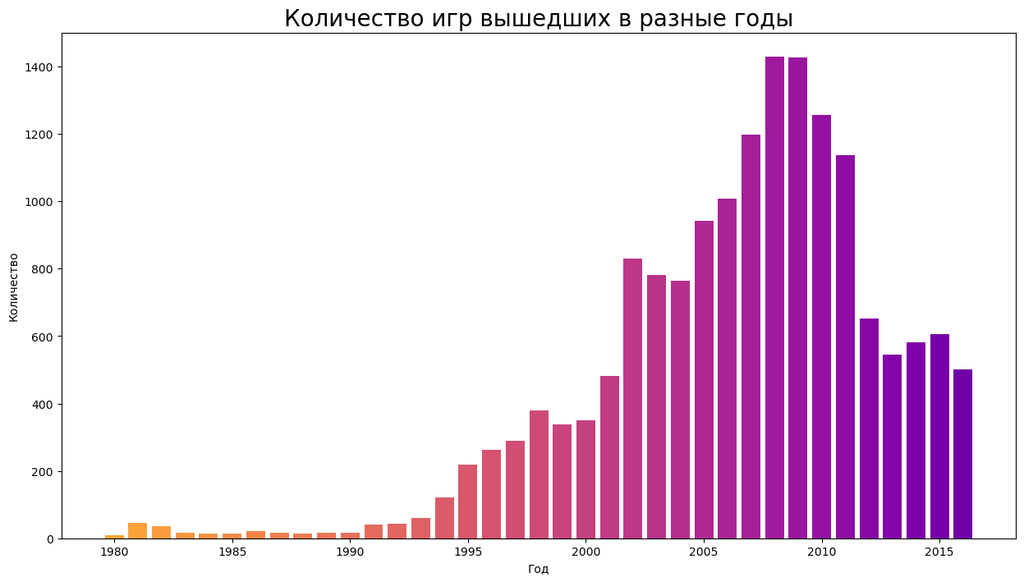

```python
#Построем содную таблицу с подсчетом количества игр, выпущенных за каждый год
year_freq = games.groupby("year_of_release").agg({"name":"count"}).reset_index()
year_freq.columns = ["year_of_release", "amount"]

#По таблице построим график распределения выпуска игр по годам
fig = plt.figure(figsize=(15, 8))
ax = fig.add_subplot()
color = cm.plasma(np.linspace(.8, .20, 38))

ax.bar("year_of_release", "amount", color=color, data=year_freq)
ax.set_ylabel('Количество')
ax.set_xlabel('Год')
ax.set_title('Количество игр вышедших в разные годы')
ax.title.set_size(20)

plt.show()
```

Так, по диаграмме можно заметить, что основное количество игр начало выпускаться примерно с 1995-2000х годов, до этого рынок видеоигр был куда менее наполнен, индустрия только зарождалась. **Пока что не стану отбрасывать ранние года, поскольку там может находиться уникальная информация, но учту данную статистику, и в зависимости от задачи отброшу или оставлю года до 1995 (или дальше).**

#### Анализ выпусков и суммарных продаж видеоигр по платформам

```python
#Составим рейтинг платформ по количеству выпущенных игр

platforms_amount = (
    games
    .groupby("platform").agg({"name":"count"})
    .reset_index()
    .sort_values(by="name", ascending = False))
platforms_amount.columns = ["platform", "amount"]
platforms_amount.head()
```

|  | platform | amount |
| --- | --- | --- |
| 16 | PS2 | 2135 |
| 4 | DS | 2122 |
| 17 | PS3 | 1305 |
| 26 | Wii | 1286 |
| 28 | X360 | 1234 |

```python
#А теперь по суммарным продажам
platforms_sales = (
    games
    .groupby("platform").agg({"sum_sales":"sum"})
    .reset_index()
    .sort_values(by="sum_sales", ascending = False))

platforms_sales.head()
```

|  | platform | sum_sales |
| --- | --- | --- |
| 16 | PS2 | 1248.12 |
| 28 | X360 | 961.30 |
| 17 | PS3 | 931.33 |
| 26 | Wii | 891.18 |
| 4 | DS | 802.79 |

```
<function matplotlib.pyplot.show(close=None, block=None)>
```

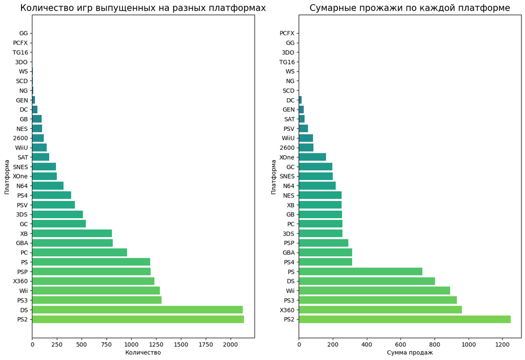

```python
#Построим графики успешности платформ по выпуску игр и по продажам
fig = plt.figure(figsize=(15, 10))
color = cm.viridis(np.linspace(.8, .20, 38))

#График по выпуску
ax1 = plt.subplot(121)
ax1.barh("platform", "amount", color=color, data=platforms_amount)
ax1.set_ylabel('Платформа')
ax1.set_xlabel('Количество')
ax1.set_title('Количество игр выпущенных на разных платформах')
ax1.title.set_size(15)

#График по продажам
ax2 = plt.subplot(122)
ax2.barh("platform", "sum_sales", color=color, data=platforms_sales)
ax2.set_ylabel('Платформа')
ax2.set_xlabel('Сумма продаж')
ax2.set_title('Сумарные прожажи по каждой платформе')
ax2.title.set_size(15)


plt.show
```

В целом, в топе по обоим критериям фигурируют одни и те же платформы. Для точности составим смешенный рейтинг, приведя распределения по обеим переменным к стандартному виду.

```python
#Стандартизируем распределения количества выпущенных игр
platforms_amount_st = platforms_amount
platforms_amount_st_x = platforms_amount_st["amount"]
platforms_amount_st["amount"] = (platforms_amount_st_x-platforms_amount_st_x.mean ())/platforms_amount_st_x.std()

#Стандартизируем распределение суммы продаж
platforms_sales_st = platforms_sales
platforms_sales_st_x = platforms_sales_st["sum_sales"]
platforms_sales_st["sum_sales"] = (platforms_sales_st_x-platforms_sales_st_x.mean ())/platforms_sales_st_x.std()
```

```python
#Соеденим два датафрейма и посчитами общий идекс, суммировав стандартизированные значения
platforms = platforms_amount_st.merge(platforms_sales_st)
platforms["index"] = platforms["amount"] + platforms["sum_sales"]
platforms = platforms.query("index > 0").sort_values(by="index", ascending=False)
platforms
```

|  | platform | amount | sum_sales | index |
| --- | --- | --- | --- | --- |
| 0 | PS2 | 2.594136 | 2.789566 | 5.383702 |
| 1 | DS | 2.573112 | 1.499868 | 4.072980 |
| 2 | PS3 | 1.251784 | 1.872126 | 3.123910 |
| 4 | X360 | 1.136956 | 1.958921 | 3.095877 |
| 3 | Wii | 1.221056 | 1.755850 | 2.976906 |
| 6 | PS | 1.065795 | 1.282056 | 2.347852 |
| 5 | PSP | 1.073882 | 0.015788 | 1.089670 |
| 7 | PC | 0.690584 | -0.083344 | 0.607240 |
| 8 | GBA | 0.452842 | 0.081065 | 0.533907 |
| 9 | XB | 0.444755 | -0.093335 | 0.351420 |

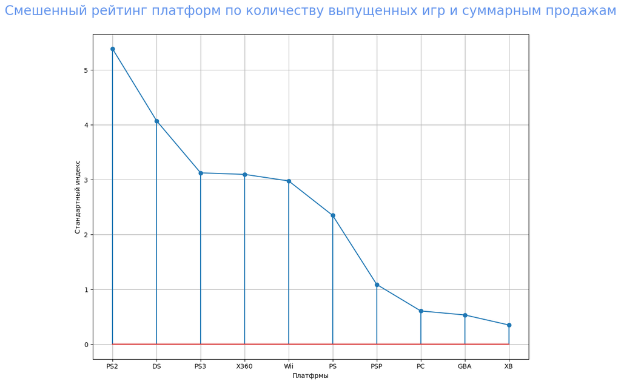

```python
#Посторем круговую диаграмму с отображением плотформ, попавших в топ по суммарному критерию
fig = plt.figure(figsize=(12, 9))
ax = fig.add_subplot()
color = cm.plasma(np.linspace(.8, .20, 38))

ax.stem("platform", "index", data=platforms)
ax.plot("platform", "index", data=platforms)
ax.set_ylabel('Стандартный индекс')
ax.set_xlabel('Платфрмы')
ax.grid(True)
ax.set_title('Смешенный рейтинг платформ по количеству выпущенных игр и суммарным продажам' + "\n", fontsize = 22, color = 'cornflowerblue')
ax.title.set_size(20)
```

Далее расмотрим, как менялись их продажи и выпуски по годам

```python
#Отбираем в массивы с выпусками и продажами те данные, которые касаются выборочных платформ
platforms_amount = platforms_amount.loc[platforms_amount["platform"].isin(list(platforms["platform"]))]
platforms_sales = platforms_sales.loc[platforms_sales["platform"].isin(list(platforms["platform"]))]

#Собираем в одну таблицу
platforms_new = platforms_amount.merge(platforms_sales)
```

Отберем в сводную таблицу 1) платформы из полученного списка 2) данные после 1995 года (т.к. на первом графике мы увидели, что до 1995 года рынок был ппрактически не активен)

```python
#Производим отбор по указанным критериям
games_slice = games.loc[(games["platform"].isin(list(platforms["platform"]))) & (games["year_of_release"] >= 1995)]

#Строим сводную таблицу с сумаррными продажами по годам
top_years = pd.pivot_table(games_slice, index="platform", columns="year_of_release", values="sum_sales", aggfunc="sum")
#Заполняем пропуски нулями для отображения на графике
top_years = top_years.fillna(0)
top_years
```

| year_of_release platform | 1995 | 1996 | 1997 | 1998 | 1999 | 2000 | 2001 | 2002 | 2003 | 2004 | ... | 2007 | 2008 | 2009 | 2010 | 2011 | 2012 | 2013 | 2014 | 2015 | 2016 |
| --- | --- | --- | --- | --- | --- | --- | --- | --- | --- | --- | --- | --- | --- | --- | --- | --- | --- | --- | --- | --- | --- |
| DS | 0.00 | 0.00 | 0.00 | 0.00 | 0.00 | 0.00 | 0.00 | 0.00 | 0.00 | 17.27 | ... | 146.94 | 145.32 | 119.54 | 85.02 | 26.18 | 11.01 | 1.54 | 0.00 | 0.00 | 0.00 |
| GBA | 0.00 | 0.00 | 0.00 | 0.00 | 0.00 | 0.07 | 61.53 | 74.16 | 56.67 | 77.91 | ... | 3.40 | 0.00 | 0.00 | 0.00 | 0.00 | 0.00 | 0.00 | 0.00 | 0.00 | 0.00 |
| PC | 4.22 | 10.58 | 11.27 | 3.26 | 4.74 | 4.66 | 5.47 | 8.57 | 8.84 | 10.39 | ... | 9.28 | 12.42 | 16.91 | 24.28 | 35.03 | 23.22 | 12.73 | 13.28 | 8.52 | 5.25 |
| PS | 35.96 | 94.70 | 136.17 | 169.49 | 144.53 | 96.37 | 35.59 | 6.67 | 2.07 | 0.00 | ... | 0.00 | 0.00 | 0.00 | 0.00 | 0.00 | 0.00 | 0.00 | 0.00 | 0.00 | 0.00 |
| PS2 | 0.00 | 0.00 | 0.00 | 0.00 | 0.00 | 39.17 | 166.43 | 205.38 | 186.77 | 220.55 | ... | 75.99 | 53.90 | 26.40 | 5.64 | 0.45 | 0.00 | 0.00 | 0.00 | 0.00 | 0.00 |
| PS3 | 0.00 | 0.00 | 0.00 | 0.00 | 0.00 | 0.00 | 0.00 | 0.00 | 0.00 | 0.00 | ... | 73.19 | 118.52 | 130.93 | 142.17 | 156.78 | 107.35 | 113.25 | 47.76 | 16.82 | 3.60 |
| PSP | 0.00 | 0.00 | 0.00 | 0.00 | 0.00 | 0.00 | 0.00 | 0.00 | 0.00 | 7.06 | ... | 46.93 | 34.56 | 38.58 | 35.04 | 17.82 | 7.69 | 3.14 | 0.24 | 0.12 | 0.00 |
| Wii | 0.00 | 0.00 | 0.00 | 0.00 | 0.00 | 0.00 | 0.00 | 0.00 | 0.00 | 0.00 | ... | 152.77 | 171.32 | 206.97 | 127.95 | 59.65 | 21.71 | 8.59 | 3.75 | 1.14 | 0.18 |
| X360 | 0.00 | 0.00 | 0.00 | 0.00 | 0.00 | 0.00 | 0.00 | 0.00 | 0.00 | 0.00 | ... | 95.42 | 135.26 | 120.29 | 170.03 | 143.89 | 99.74 | 88.58 | 34.74 | 11.96 | 1.52 |
| XB | 0.00 | 0.00 | 0.00 | 0.00 | 0.00 | 0.99 | 22.26 | 48.59 | 55.40 | 65.42 | ... | 0.55 | 0.18 | 0.00 | 0.00 | 0.00 | 0.00 | 0.00 | 0.00 | 0.00 | 0.00 |

10 rows × 22 columns

```python
top_years
```

| year_of_release platform | 1995 | 1996 | 1997 | 1998 | 1999 | 2000 | 2001 | 2002 | 2003 | 2004 | ... | 2007 | 2008 | 2009 | 2010 | 2011 | 2012 | 2013 | 2014 | 2015 | 2016 |
| --- | --- | --- | --- | --- | --- | --- | --- | --- | --- | --- | --- | --- | --- | --- | --- | --- | --- | --- | --- | --- | --- |
| DS | 0.00 | 0.00 | 0.00 | 0.00 | 0.00 | 0.00 | 0.00 | 0.00 | 0.00 | 17.27 | ... | 146.94 | 145.32 | 119.54 | 85.02 | 26.18 | 11.01 | 1.54 | 0.00 | 0.00 | 0.00 |
| GBA | 0.00 | 0.00 | 0.00 | 0.00 | 0.00 | 0.07 | 61.53 | 74.16 | 56.67 | 77.91 | ... | 3.40 | 0.00 | 0.00 | 0.00 | 0.00 | 0.00 | 0.00 | 0.00 | 0.00 | 0.00 |
| PC | 4.22 | 10.58 | 11.27 | 3.26 | 4.74 | 4.66 | 5.47 | 8.57 | 8.84 | 10.39 | ... | 9.28 | 12.42 | 16.91 | 24.28 | 35.03 | 23.22 | 12.73 | 13.28 | 8.52 | 5.25 |
| PS | 35.96 | 94.70 | 136.17 | 169.49 | 144.53 | 96.37 | 35.59 | 6.67 | 2.07 | 0.00 | ... | 0.00 | 0.00 | 0.00 | 0.00 | 0.00 | 0.00 | 0.00 | 0.00 | 0.00 | 0.00 |
| PS2 | 0.00 | 0.00 | 0.00 | 0.00 | 0.00 | 39.17 | 166.43 | 205.38 | 186.77 | 220.55 | ... | 75.99 | 53.90 | 26.40 | 5.64 | 0.45 | 0.00 | 0.00 | 0.00 | 0.00 | 0.00 |
| PS3 | 0.00 | 0.00 | 0.00 | 0.00 | 0.00 | 0.00 | 0.00 | 0.00 | 0.00 | 0.00 | ... | 73.19 | 118.52 | 130.93 | 142.17 | 156.78 | 107.35 | 113.25 | 47.76 | 16.82 | 3.60 |
| PSP | 0.00 | 0.00 | 0.00 | 0.00 | 0.00 | 0.00 | 0.00 | 0.00 | 0.00 | 7.06 | ... | 46.93 | 34.56 | 38.58 | 35.04 | 17.82 | 7.69 | 3.14 | 0.24 | 0.12 | 0.00 |
| Wii | 0.00 | 0.00 | 0.00 | 0.00 | 0.00 | 0.00 | 0.00 | 0.00 | 0.00 | 0.00 | ... | 152.77 | 171.32 | 206.97 | 127.95 | 59.65 | 21.71 | 8.59 | 3.75 | 1.14 | 0.18 |
| X360 | 0.00 | 0.00 | 0.00 | 0.00 | 0.00 | 0.00 | 0.00 | 0.00 | 0.00 | 0.00 | ... | 95.42 | 135.26 | 120.29 | 170.03 | 143.89 | 99.74 | 88.58 | 34.74 | 11.96 | 1.52 |
| XB | 0.00 | 0.00 | 0.00 | 0.00 | 0.00 | 0.99 | 22.26 | 48.59 | 55.40 | 65.42 | ... | 0.55 | 0.18 | 0.00 | 0.00 | 0.00 | 0.00 | 0.00 | 0.00 | 0.00 | 0.00 |

10 rows × 22 columns

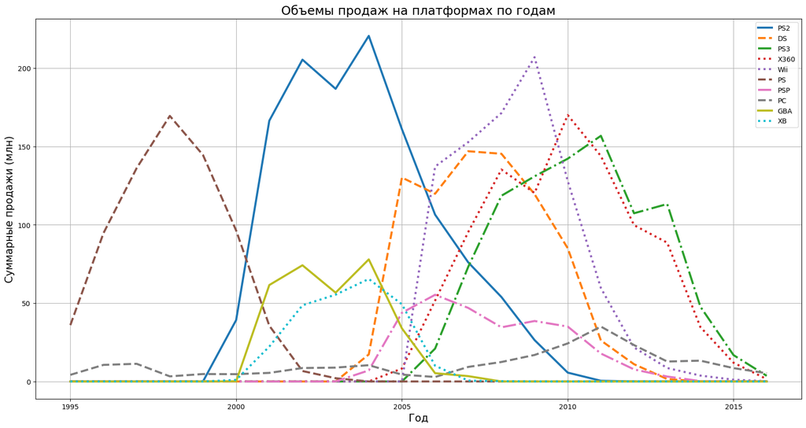

```python
#Посторим график объема продаж по каждой из выбранных  платформ
styles = ["-", "--", "-.", ":", "dotted", "dashed", "dashdot", "--", "solid", ":"]

#Создаем поле для графика
fig, ax = plt.subplots(figsize=(20, 10))

#Строим графики по каждой из платформ за выделенный период
for style, plat in enumerate(list(platforms["platform"])):
    ax = top_years.loc[plat]
    plt.plot(top_years.columns, ax, label=plat, linestyle=styles[style], linewidth=3)
    plt.title('Объемы продаж на платформах по годам', fontsize=18)
    plt.xlabel('Год', fontsize=15)
    plt.ylabel('Суммарные продажи (млн)', fontsize=15)
    plt.legend()
    plt.grid(True)
```

Итак, по построенному графику мы видим, что объем продаж по платформам имеет парабалическую форму: т.е. объем продаж каждой платформы взлетает на определенное время, а затем платформа устаревает, и продажи падают. По графику видно, что примерный период роста и спада составляет **10 лет.**

Также по диаграмме мы видем, что устаревшие платформы потеряли свою актуальность примерно к 2014 году. Приблизительно в это же время должен начаться период зарожддения новых платформ.

```python
#Отбрасываем данные до 2007
games_actual = games.loc[games["year_of_release"] >= 2014]
```

Далее повторим раннее прописанный блок кода, только уже на новых данных.

```python
#Составим рейтинг платформ по количеству выпущенных игр

platforms_amount = (
    games_actual
    .groupby("platform").agg({"name":"count"})
    .reset_index()
    .sort_values(by="name", ascending = False))
platforms_amount.columns = ["platform", "amount"]

#А теперь по суммарным продажам
platforms_sales = (
    games_actual
    .groupby("platform").agg({"sum_sales":"sum"})
    .reset_index()
    .sort_values(by="sum_sales", ascending = False))

#Стандартизируем распределения количества выпущенных игр
platforms_amount_st = platforms_amount
platforms_amount_st_x = platforms_amount_st["amount"]
platforms_amount_st["amount"] = (platforms_amount_st_x-platforms_amount_st_x.mean ())/platforms_amount_st_x.std()

#Стандартизируем распределение суммы продаж
platforms_sales_st = platforms_sales
platforms_sales_st_x = platforms_sales_st["sum_sales"]
platforms_sales_st["sum_sales"] = (platforms_sales_st_x-platforms_sales_st_x.mean ())/platforms_sales_st_x.std()

#Соеденим два датафрейма и посчитами общий идекс, суммировав стандартизированные значения
platforms_new = platforms_amount_st.merge(platforms_sales_st)
platforms_new["index"] = platforms_new["amount"] + platforms_new["sum_sales"]
platforms_new = platforms_new.loc[:10]
platforms_new
```

|  | platform | amount | sum_sales | index |
| --- | --- | --- | --- | --- |
| 0 | PS4 | 1.731461 | 2.492085 | 4.223546 |
| 1 | PSV | 1.054260 | -0.585314 | 0.468946 |
| 2 | XOne | 0.494106 | 0.780669 | 1.274775 |
| 3 | PS3 | 0.418861 | -0.055179 | 0.363682 |
| 4 | 3DS | 0.360338 | 0.159052 | 0.519390 |
| 5 | PC | -0.149653 | -0.531466 | -0.681120 |
| 6 | X360 | -0.484073 | -0.286317 | -0.770390 |
| 7 | WiiU | -0.801773 | -0.346996 | -1.148769 |
| 8 | PSP | -1.303403 | -0.840538 | -2.143941 |
| 9 | Wii | -1.320124 | -0.785996 | -2.106120 |

После удаления 19 лет можно заметить, что полученный актуальный рейтинг значительно изменился, некоторые платформы ушли, а новые - появились. Теперь список состоит из следующих представителей: **'PS4', 'PSV', 'XOne', 'PS3', '3DS', 'PC', 'X360', 'WiiU', 'PSP', 'Wii'**

Рассмотрим успехи данных платформ в производстве и продаже видеоигр на диаграмме размаха

```python
#Изменим количество знаков после запятой
pd.set_option("display.precision", 2)

#Производим отбор по указанным критериям
games_slice2 = games_actual.loc[games_actual["platform"].isin(list(platforms_new["platform"]))]

top_years2 = games_slice2[["platform", "sum_sales", "year_of_release"]].set_index("platform")
games_slice2
```

|  | name | platform | year_of_release | genre | na_sales | eu_sales | jp_sales | other_sales | critic_score | user_score | rating | sum_sales | no_scored |
| --- | --- | --- | --- | --- | --- | --- | --- | --- | --- | --- | --- | --- | --- |
| 31 | Call of Duty: Black Ops 3 | PS4 | 2015 | Shooter | 6.03 | 5.86 | 0.36 | 2.38 | 0.0 | 0.0 | 0 | 14.63 | 1 |
| 42 | Grand Theft Auto V | PS4 | 2014 | Action | 3.96 | 6.31 | 0.38 | 1.97 | 97.0 | 8.3 | M | 12.62 | 0 |
| 47 | Pokemon Omega Ruby/Pokemon Alpha Sapphire | 3DS | 2014 | Role-Playing | 4.35 | 3.49 | 3.10 | 0.74 | 0.0 | 0.0 | 0 | 11.68 | 1 |
| 77 | FIFA 16 | PS4 | 2015 | Sports | 1.12 | 6.12 | 0.06 | 1.28 | 82.0 | 4.3 | E | 8.58 | 0 |
| 87 | Star Wars Battlefront (2015) | PS4 | 2015 | Shooter | 2.99 | 3.49 | 0.22 | 1.28 | 0.0 | 0.0 | 0 | 7.98 | 1 |
| ... | ... | ... | ... | ... | ... | ... | ... | ... | ... | ... | ... | ... | ... |
| 16703 | Strawberry Nauts | PSV | 2016 | Adventure | 0.00 | 0.00 | 0.01 | 0.00 | 0.0 | 0.0 | 0 | 0.01 | 1 |
| 16707 | Aiyoku no Eustia | PSV | 2014 | Misc | 0.00 | 0.00 | 0.01 | 0.00 | 0.0 | 0.0 | 0 | 0.01 | 1 |
| 16710 | Samurai Warriors: Sanada Maru | PS3 | 2016 | Action | 0.00 | 0.00 | 0.01 | 0.00 | 0.0 | 0.0 | 0 | 0.01 | 1 |
| 16712 | Haitaka no Psychedelica | PSV | 2016 | Adventure | 0.00 | 0.00 | 0.01 | 0.00 | 0.0 | 0.0 | 0 | 0.01 | 1 |
| 16714 | Winning Post 8 2016 | PSV | 2016 | Simulation | 0.00 | 0.00 | 0.01 | 0.00 | 0.0 | 0.0 | 0 | 0.01 | 1 |

1689 rows × 13 columns

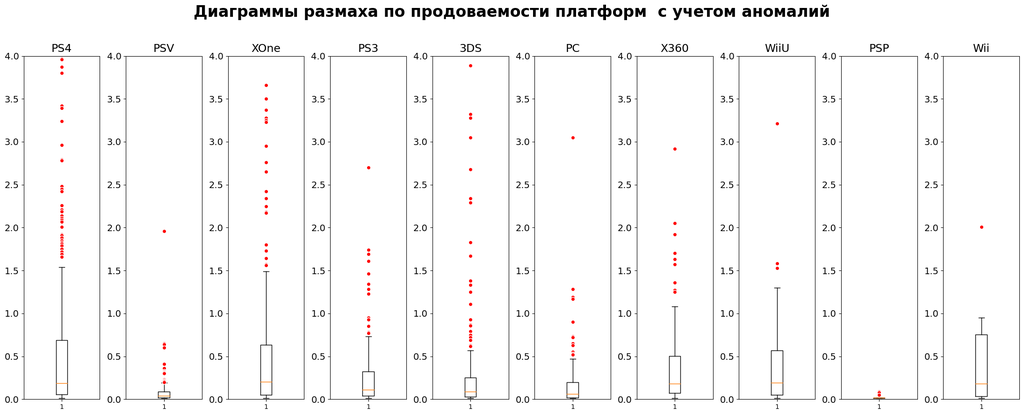

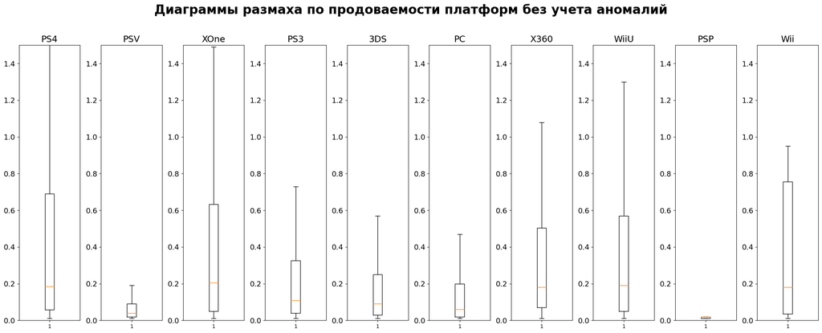

```python
#Устанавливаем цвет и маркер для обозначения выбросов
red_circle = dict(markerfacecolor='red', marker='o', markeredgecolor='white')

plat = list(platforms_new["platform"])

#Создаем поле для графика
fig, axs = plt.subplots(1, len(list(platforms_new["platform"])), figsize=(22, 9))
fig.suptitle('Диаграммы размаха по продоваемости платформ  с учетом аномалий' + '\n', fontsize=24, fontweight='bold')
top_years3 = top_years2['sum_sales']

#Строим графики по каждой из платформ за выделенный период
for i, ax in enumerate(axs.flat):
    ax.boxplot(top_years3.loc[plat[i]], flierprops = red_circle)
    ax.set_title(plat[i], fontsize=17)
    ax.tick_params(axis="y", labelsize=14)
    ax.set_ylim([0, 4])



plt.tight_layout()


#Устанавливаем цвет и маркер для обозначения выбросов
red_circle = dict(markerfacecolor='red', marker='o', markeredgecolor='white')

plat = list(platforms_new["platform"])

#Создаем поле для графика
fig, axs = plt.subplots(1, len(list(platforms_new["platform"])), figsize=(22, 9))
fig.suptitle('Диаграммы размаха по продоваемости платформ без учета аномалий' + '\n', fontsize=24, fontweight='bold')
top_years3 = top_years2['sum_sales']

#Строим графики по каждой из платформ за выделенный период
for i, ax in enumerate(axs.flat):
    ax.boxplot(top_years3.loc[plat[i]], flierprops = red_circle, showfliers=False)
    ax.set_title(plat[i], fontsize=17)
    ax.tick_params(axis="y", labelsize=14)
    ax.set_ylim([0, 1.5])



plt.tight_layout()
```

Диаграмм размаха недостаточно для того, чтобы сделать вывод о прогнозе, потому что не известно к какому году относятся наблюдаемые аномалии (например у WiiU). В связи с чем ниже еще раз отобразим линейный график, построенный на новых данных

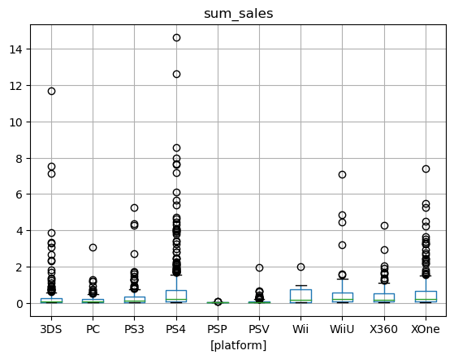

```python
# check
games_actual[['sum_sales','platform']].boxplot(by='platform')
plt.suptitle("");
```

```python
top_plat = pd.pivot_table(games_slice2, index="platform", columns="year_of_release", values="sum_sales")
#Заполняем пропуски нулями для отображения на графике
top_plat = top_plat.fillna(0)
```

[figure not shown]

```python
styles = ["-", "--", "-.", ":", "dotted", "dashed", "dashdot", "--", "solid", ":", "dotted"]

#Создаем поле для графика
fig, ax = plt.subplots(figsize=(20, 10))

#Строим графики по каждой из платформ за выделенный период
for style, plat in enumerate(list(platforms_new["platform"])):
    ax = top_plat.loc[plat]
    plt.plot(top_plat.columns, ax, label=plat, linestyle=styles[style], linewidth=3)
    plt.title('Объемы продаж на платформах по годам', fontsize=18)
    plt.xlabel('Год', fontsize=15)
    plt.ylabel('Суммарные продажи (млн)', fontsize=15)
    plt.legend()
    plt.grid(True)
```

*Таким образом мы видим, что:*

2) WiiU также держиться в середине рейтинга по продажам, мене стабильно чем ПК, но более прибыльно, что делает ее перспективной на 2017 год.

3) Платформа 3DS хоть и демонстрирует явный спад, еще не до конца потеряла свою актуальность, всвязи с чем е тоже можно считать прибыльной на 2017 год.

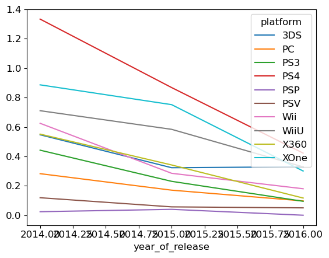

```python
top_plat.T.plot(kind='line')
```

#### Анализ влияния отзывов на продажи видеоигр

Рассмотрим далее как влияют отзывы пользователей и критиков на продажи видеоигр. **Исслоедовательская гипотеза: рейтинги пользователей и критиков оказывают вдияние на объем продаж**

Сделаем оценку на примере одной платформы. В качестве таковой возьмем PC, как наиболее стабильную.

```python
#Сделаем срез данных по выбранной платформе
games_pc = games.loc[(games["platform"] == "PC") & (games["no_scored"] == 0)]
games_pc.head()
```

|  | name | platform | year_of_release | genre | na_sales | eu_sales | jp_sales | other_sales | critic_score | user_score | rating | sum_sales | no_scored |
| --- | --- | --- | --- | --- | --- | --- | --- | --- | --- | --- | --- | --- | --- |
| 85 | The Sims 3 | PC | 2009 | Simulation | 0.99 | 6.42 | 0.00 | 0.60 | 86.0 | 7.6 | T | 8.01 | 0 |
| 138 | World of Warcraft | PC | 2004 | Role-Playing | 0.08 | 6.21 | 0.00 | 0.00 | 93.0 | 7.3 | T | 6.29 | 0 |
| 192 | Diablo III | PC | 2012 | Role-Playing | 2.44 | 2.16 | 0.00 | 0.54 | 88.0 | 4.0 | M | 5.14 | 0 |
| 218 | StarCraft II: Wings of Liberty | PC | 2010 | Strategy | 2.57 | 1.68 | 0.00 | 0.58 | 93.0 | 8.2 | T | 4.83 | 0 |
| 284 | Half-Life | PC | 1997 | Shooter | 4.03 | 0.00 | 0.09 | 0.00 | 96.0 | 9.1 | M | 4.12 | 0 |

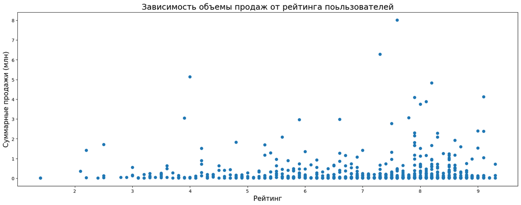

```python
#Строим диаграмму рассеяния
fig, ax = plt.subplots(figsize=(20, 7))

ax.scatter("user_score", "sum_sales", data = games_pc)
plt.title('Зависимость объемы продаж от рейтинга поьльзователей', fontsize=18)
plt.xlabel('Рейтинг', fontsize=15)
plt.ylabel('Суммарные продажи (млн)', fontsize=15)
```

```python
#Определяем корреляцию между текущеми переменными
round(games_pc['user_score'].corr(games_pc['sum_sales']), 2)
```

```
0.01
```

Корреляция слабая отсутствует: значение близко к нулю. Рассмотрим, что касается оценок критиков

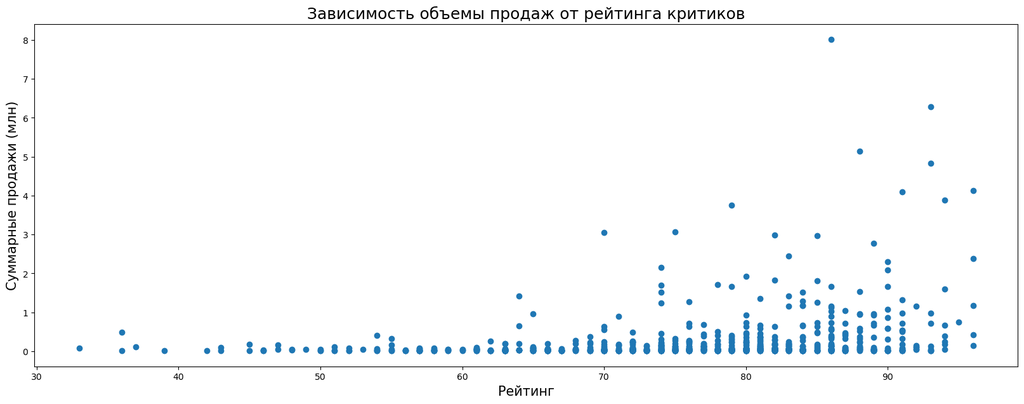

```python
#Строим диаграмму рассеяния
fig, ax = plt.subplots(figsize=(20, 7))

ax.scatter("critic_score", "sum_sales", data = games_pc)
plt.title('Зависимость объемы продаж от рейтинга критиков', fontsize=18)
plt.xlabel('Рейтинг', fontsize=15)
plt.ylabel('Суммарные продажи (млн)', fontsize=15)
```

```python
#Определяем корреляцию между текущеми переменными
round(games_pc['critic_score'].corr(games_pc['sum_sales']), 2)
```

```
0.26
```

Корреляция продаж с оценками критиков выше. Ее можно назвать умеренной. В данном случае, касаемо ПК игр, оценки критиков имеют значение для продаж, но не однозначное.

Сравним как коррелируют данный показатели на других платформах

```python
#Выведем топы платформ по выпускам игр и продажам
amount = games.loc[games["platform"].isin(list(platforms_new["platform"]))].groupby("platform")["name"].count().sort_values(ascending=False)
print(amount)

sales = games.loc[games["platform"].isin(list(platforms_new["platform"]))].groupby("platform")["sum_sales"].sum().sort_values(ascending=False)
print(sales)
```

```
platform
PS3     1305
Wii     1286
X360    1234
PSP     1195
PC       958
3DS      512
PSV      429
PS4      392
XOne     247
WiiU     147
Name: name, dtype: int64
platform
X360    961.30
PS3     931.33
Wii     891.18
PS4     314.14
PSP     290.34
3DS     257.81
PC      256.11
XOne    159.32
WiiU     82.19
PSV      53.81
Name: sum_sales, dtype: float64
```

```python
#Напишем функции для:

#Вывода двух диаграмм рассеяния для взаимосвязи пользовательского рейтинга и рейтинга критиков с продажами
def platform_rating_plot(platform_name):
    platform = games.loc[(games['platform']==platform_name) & (games["no_scored"] == 0)]
    fig, ax = plt.subplots(1 ,2, figsize=(15,5))
    sns.scatterplot(x='user_score', y='sum_sales', data=platform, ax=ax[0], color = "slateblue")
    sns.scatterplot(x='critic_score', y='sum_sales', data=platform, ax=ax[1], color = "darkorchid")
    fig.suptitle(platform_name, fontsize=15)
    ax[0].set(xlabel='Оценка пользователей')
    ax[1].set(xlabel='Оценка критиков')
    ax[0].set(ylabel='Количество продаж')
    ax[1].set(ylabel='Количество продаж')
    plt.show()

#Вывода и сохранения корреляции между пользовательским рейтингом и продажами
def check_correlation_users(platform_name, flag):
    platform = games.loc[(games['platform']==platform_name) & (games["no_scored"] == 0)]
    if flag == 1:
        print("Корреляция продаж с пользовательским рейтингом:", round(platform["user_score"].corr(platform['sum_sales']), 2))
    if flag == 0:
        return platform["user_score"].corr(platform['sum_sales'])

#Вывода и сохранения корреляции между рейтингом критиков и продажами
def check_correlation_critics(platform_name, flag):
    platform = games.loc[(games['platform']==platform_name) & (games["no_scored"] == 0)]
    if flag == 1:
        print("Корреляция продаж с рейтингом критиков:", round(platform["critic_score"].corr(platform['sum_sales']),2))
    if flag == 0:
        return platform["critic_score"].corr(platform['sum_sales'])
```

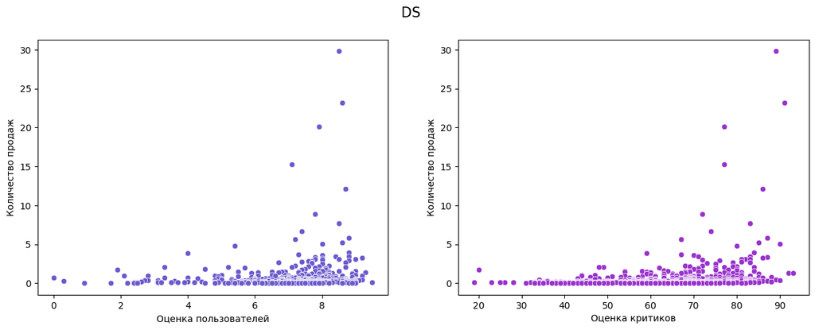

```
Корреляция продаж с пользовательским рейтингом: 0.13
Корреляция продаж с рейтингом критиков: 0.24
```

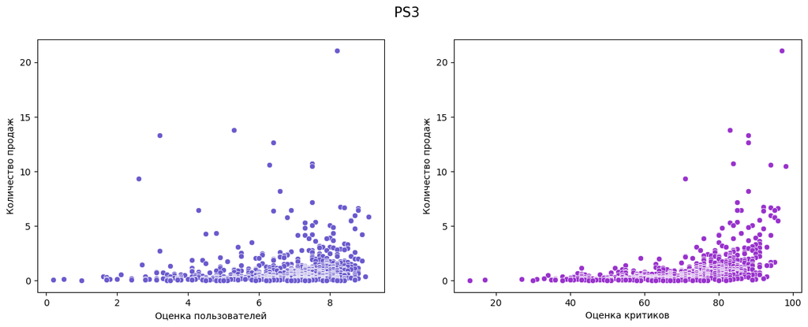

```
Корреляция продаж с пользовательским рейтингом: 0.13
Корреляция продаж с рейтингом критиков: 0.43
```

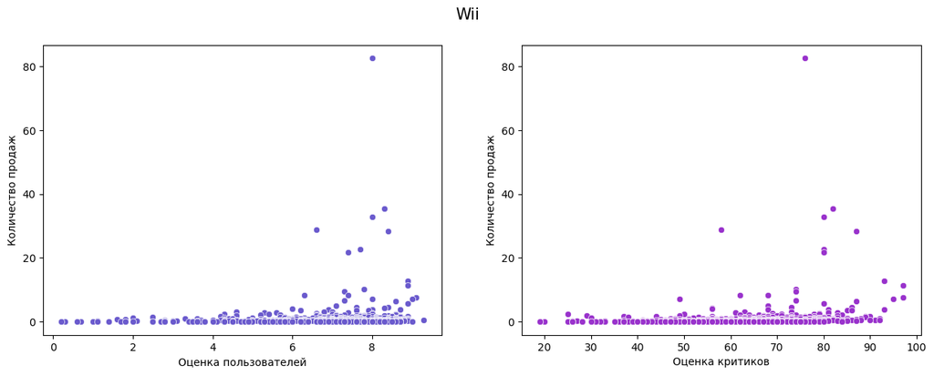

```
Корреляция продаж с пользовательским рейтингом: 0.11
Корреляция продаж с рейтингом критиков: 0.18
```

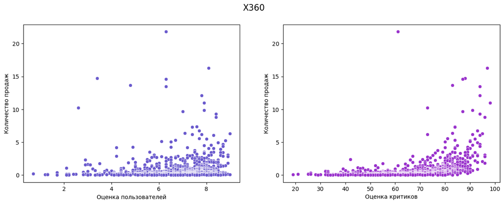

```
Корреляция продаж с пользовательским рейтингом: 0.11
Корреляция продаж с рейтингом критиков: 0.39
```

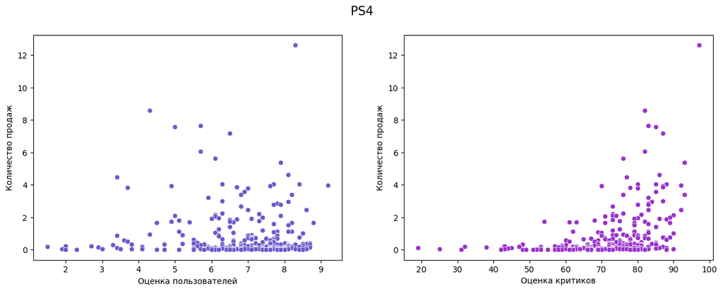

```
Корреляция продаж с пользовательским рейтингом: -0.03
Корреляция продаж с рейтингом критиков: 0.41
```

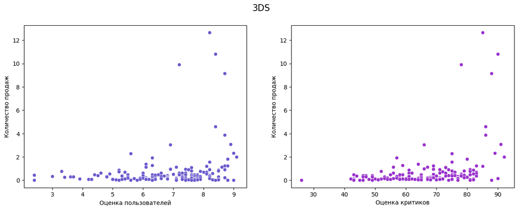

```
Корреляция продаж с пользовательским рейтингом: 0.22
Корреляция продаж с рейтингом критиков: 0.35
```

```python
#Создадим списки для сохранения корреляций
user_corr = []
critic_corr = []

#Создадим переменную с выборочными элементами
score = ["DS", "PS3", "Wii", "X360", "PS4", "3DS"]

#Для каждого элемента построим графики, выведем и сохраним корреляцию
for element in score:
    platform_rating_plot(element)
    check_correlation_users(element, 1)
    check_correlation_critics(element, 1)

    user_corr.append(check_correlation_users(element, 0))
    critic_corr.append(check_correlation_critics(element, 0))
```

```
Среднее влияние пользовательского рейтинга на продажи: 0.11259467950039768
Стандартное отклонение влияния пользовательского рейтинга на продажи: 0.08179573570946086

Среднее влияние рейтинга критиков на продажи: 0.3329371514138369
Стандартное отклонение влияния рейтинга критиков на продажи: 0.10255359242893396
```

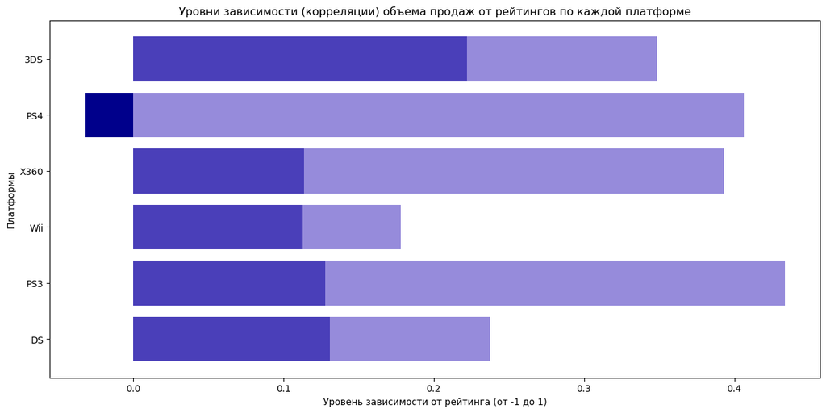

```python
#Выведем на столбчатой диаграмме значения корреляций по каждому элементу для обеих зависимостей

fig, ax = plt.subplots(figsize=(15, 7))
plt.barh(score, user_corr, color="darkblue")
plt.barh(score, critic_corr, alpha = 0.7, color="slateblue")

#А также выведем среднее и стандартное отклонение между корреляциями в группе отдельной зависимости
print("Среднее влияние пользовательского рейтинга на продажи:", pd.Series(user_corr).mean())
print("Стандартное отклонение влияния пользовательского рейтинга на продажи:", pd.Series(user_corr).std())
print()
print("Среднее влияние рейтинга критиков на продажи:", pd.Series(critic_corr).mean())
print("Стандартное отклонение влияния рейтинга критиков на продажи:", pd.Series(critic_corr).std())

ax.set_ylabel('Платформы')
ax.set_xlabel('Уровень зависимости от рейтинга (от -1 до 1)')
ax.set_title('Уровни зависимости (корреляции) объема продаж от рейтингов по каждой платформе')
```